# Индивидуальный проект этап № 1

Установка дистрибутива Kali Linux на виртуальную машину VirtualBox

Мальянц Виктория Кареновна

1132246740@rudn.ru

Российский университет дружбы народов

2026-02-25

# Цель работы

- Установить дистрибутив Kali Linux на виртуальную машину VirtualBox

# Задание

- Установить дистрибутив Kali Linux на виртуальную машину VirtualBox

# Выполнение лабораторной работы

## Установить дистрибутив Kali Linux на виртуальную машину VirtualBox

- Скачала образ диска (рис. 1).

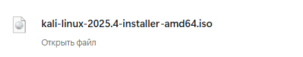

Образ диска

## Установить дистрибутив Kali Linux на виртуальную машину VirtualBox

- Выбираю имя и тип ОС (рис. 2).

[figure not shown]

Выбор имени и типа ОС

## Установить дистрибутив Kali Linux на виртуальную машину VirtualBox

- Выбираю графическую установку (рис. 3).

[figure not shown]

Выбор графической установки

## Установить дистрибутив Kali Linux на виртуальную машину VirtualBox

- Выбираю русский язык, на нем буду устанавливать (рис. 4).

[figure not shown]

Выбор языка

## Установить дистрибутив Kali Linux на виртуальную машину VirtualBox

- Выбираю местоположение (рис. 5).

[figure not shown]

Выбор местоположения

## Установить дистрибутив Kali Linux на виртуальную машину VirtualBox

- Настраиваю клавиатуру (рис. 6).

[figure not shown]

Настройка клавиатуры

## Установить дистрибутив Kali Linux на виртуальную машину VirtualBox

- Указываю способ переключения клавиатуры (рис. 7).

[figure not shown]

Указание способа переключения клавиатуры

## Установить дистрибутив Kali Linux на виртуальную машину VirtualBox

[figure not shown]

## Установить дистрибутив Kali Linux на виртуальную машину VirtualBox

- Ввожу имя домена (рис. 9).

[figure not shown]

Ввод имени домена

## Установить дистрибутив Kali Linux на виртуальную машину VirtualBox

- Ввожу полное имя нового пользователя (рис. 10).

[figure not shown]

Ввод полного имени нового пользователя

## Установить дистрибутив Kali Linux на виртуальную машину VirtualBox

- Выбираю имя учетной записи (рис. 11).

[figure not shown]

Выбор имени учетной записи

## Установить дистрибутив Kali Linux на виртуальную машину VirtualBox

- Создаю пароль (рис. 12).

[figure not shown]

Создание пароля

## Установить дистрибутив Kali Linux на виртуальную машину VirtualBox

- Настраиваю время (рис. 13).

[figure not shown]

Настройка времени

## Установить дистрибутив Kali Linux на виртуальную машину VirtualBox

- Выбираю метод разметки (рис. 14).

[figure not shown]

Выбор метода разметки

## Установить дистрибутив Kali Linux на виртуальную машину VirtualBox

- Выбираю диск для разметки (рис. 15).

[figure not shown]

Выбор диска для разметки

## Установить дистрибутив Kali Linux на виртуальную машину VirtualBox

- Выбираю схему разметки (рис. 16).

[figure not shown]

Выбор схемы разметки

## Установить дистрибутив Kali Linux на виртуальную машину VirtualBox

- Заканчиваю разметку и записываю изменения на диск (рис. 17).

[figure not shown]

Заканчивание разметки и записывание изменения на диск

## Установить дистрибутив Kali Linux на виртуальную машину VirtualBox

- Записываю изменения на диск (рис. 18).

[figure not shown]

Запись изменений на диск

## Установить дистрибутив Kali Linux на виртуальную машину VirtualBox

- Выбираю программное обеспечение (рис. 19).

[figure not shown]

Выбор программного обеспечения

## Установить дистрибутив Kali Linux на виртуальную машину VirtualBox

- Устанавливаю системный загрузчик GRUB на первичный диск (рис. 20).

[figure not shown]

Установка системного загрузчика GRUB на первичный диск

## Установить дистрибутив Kali Linux на виртуальную машину VirtualBox

- Указываю устройство установки системного загрузчика (рис. 21).

[figure not shown]

Указание устройства установки системного загрузчика

## Установить дистрибутив Kali Linux на виртуальную машину VirtualBox

- Вхожу в учетную запись (рис. 22).

[figure not shown]

Вход в учетную запись

## Установить дистрибутив Kali Linux на виртуальную машину VirtualBox

- В носителях теперь пусто (рис. 23).

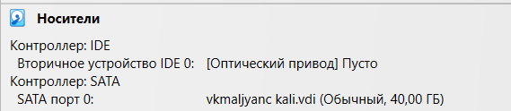

Носители

## Установить дистрибутив Kali Linux на виртуальную машину VirtualBox

- Загрузка и вход в систему выполнены успешно (рис. 24).

[figure not shown]

Успешный вход в систему

# Выводы

- Я установила дистрибутив Kali Linux на виртуальную машину VirtualBox.

# Спасибо за внимание